# CENTRO UNIVERSITÁRIO 7 DE SETEMBRO

# Especialização em Ciência de Dados com Big Data, BI e Data Analytics

# Disciplina: Análise Estatística de Dados

# Professor: Prof. Dr. Marcio Mota

## Equipe:

# Questão 3 (4 pontos):

Desenvolva uma aplicação simulada em que a Regressão Logística seja a técnica de Análise Multivariada de Dados mais adequada para encontrar a Probabilidade do Evento $[p(evento)]$ ocorrer. Indique a variável dependente e, pelo menos, três variáveis independentes estatisticamente significantes que possam apontar o (a) aumento/diminuição de chance de identificar a probabilidade do $p(evento)$. Indique todos os testes adequados, apresente a Tabela de Classificação com VP, FP, FN e VN e as medidas de desempenho. Crie uma regra de classificação e apresente a solução da Regra de Negócio da simulação.

## Dataset

- Fonte: https://www.kaggle.com/uciml/pima-indians-diabetes-database
- Contexto:
  - Esse conjunto de dados é original do *National Institute of Diabetes and Digestive and Kidney Diseases* da Índia. O objetivo do conjunto de dados é predizer se um paciente tem ou não tem diabetes, com base em certas medições de diagnóstico incluídas no conjunto de dados. Várias restrições foram colocadas na seleção dessas instâncias em um banco de dados maior. Em particular, todos os pacientes aqui são mulheres com pelo menos 21 anos de idade da herança indígena Pima.
- Conteúdo:
  - **#Pregnancies**: Número de gravidez
  - **#Glucose**: Concentração de glucose no plasma duas horas em um teste oral de tolerância à glicose
  - **#BloodPressure**: Pressão sanguínea diastólica (mm Hg)
  - **#SkinThickness**: Espessura da dobra da pele do tríceps (mm)
  - **#Insulin**: Insulina sérica de 2 horas (mu U/ml)
  - **#BMI**: Índice de massa corporal $(\frac{peso (kg)}{altura (m^2)})$
  - **#DiabetesPedigreeFunction**: Função pedigree do diabetes
    - Diabetes Pedigree Function (DPF), valores que medem a tendência ao desenvolvimento de diabetes com base nas relações genéticas do indivíduo
  - #**Age**: Idade em anos
  - #**Diabetes**: A variável de classe (0 ou 1) 268 de 768 é 1 (tem diabetes), as outras são 0 (não tem diabetes)

```python
import pandas as pd
import numpy as np

num_format = "{:>2.2f}".format
```

```python
# Carregar dados
df = pd.read_csv('https://www.dropbox.com/s/tfd380rtyx5mx9l/datasets_228_482_diabetes.csv?dl=1')

col_names = ['pregnant', 'glucose', 'bp', 'skin', 'insulin', 'bmi', 'pedigree', 'age', 'diabetes']
df.columns = col_names
```

# Estrutura das informações Diabetes

```python
df
```

|  | pregnant | glucose | bp | skin | insulin | bmi | pedigree | age | diabetes |
| --- | --- | --- | --- | --- | --- | --- | --- | --- | --- |
| 0 | 6 | 148 | 72 | 35 | 0 | 33.6 | 0.627 | 50 | 1 |
| 1 | 1 | 85 | 66 | 29 | 0 | 26.6 | 0.351 | 31 | 0 |
| 2 | 8 | 183 | 64 | 0 | 0 | 23.3 | 0.672 | 32 | 1 |
| 3 | 1 | 89 | 66 | 23 | 94 | 28.1 | 0.167 | 21 | 0 |
| 4 | 0 | 137 | 40 | 35 | 168 | 43.1 | 2.288 | 33 | 1 |
| ... | ... | ... | ... | ... | ... | ... | ... | ... | ... |
| 763 | 10 | 101 | 76 | 48 | 180 | 32.9 | 0.171 | 63 | 0 |
| 764 | 2 | 122 | 70 | 27 | 0 | 36.8 | 0.340 | 27 | 0 |
| 765 | 5 | 121 | 72 | 23 | 112 | 26.2 | 0.245 | 30 | 0 |
| 766 | 1 | 126 | 60 | 0 | 0 | 30.1 | 0.349 | 47 | 1 |
| 767 | 1 | 93 | 70 | 31 | 0 | 30.4 | 0.315 | 23 | 0 |

768 rows × 9 columns

# Estatística Descritiva dos Dados

```python
df.describe()
```

|  | pregnant | glucose | bp | skin | insulin | bmi | pedigree | age | diabetes |
| --- | --- | --- | --- | --- | --- | --- | --- | --- | --- |
| count | 768.000000 | 768.000000 | 768.000000 | 768.000000 | 768.000000 | 768.000000 | 768.000000 | 768.000000 | 768.000000 |
| mean | 3.845052 | 120.894531 | 69.105469 | 20.536458 | 79.799479 | 31.992578 | 0.471876 | 33.240885 | 0.348958 |
| std | 3.369578 | 31.972618 | 19.355807 | 15.952218 | 115.244002 | 7.884160 | 0.331329 | 11.760232 | 0.476951 |
| min | 0.000000 | 0.000000 | 0.000000 | 0.000000 | 0.000000 | 0.000000 | 0.078000 | 21.000000 | 0.000000 |
| 25% | 1.000000 | 99.000000 | 62.000000 | 0.000000 | 0.000000 | 27.300000 | 0.243750 | 24.000000 | 0.000000 |
| 50% | 3.000000 | 117.000000 | 72.000000 | 23.000000 | 30.500000 | 32.000000 | 0.372500 | 29.000000 | 0.000000 |
| 75% | 6.000000 | 140.250000 | 80.000000 | 32.000000 | 127.250000 | 36.600000 | 0.626250 | 41.000000 | 1.000000 |
| max | 17.000000 | 199.000000 | 122.000000 | 99.000000 | 846.000000 | 67.100000 | 2.420000 | 81.000000 | 1.000000 |

# Seleção de Variáveis

- Variáveis Independentes: $pregnant,glucose,bp,skin,insulin,bmi,pedigree,age$
- Variável Dependente: $diabetes$

## Identificar as variáveis estatísticamente mais significativas:

```python
import statsmodels.api as sm
import statsmodels.formula.api as smf

modelo = smf.glm(formula='diabetes ~ pregnant + glucose + bp + skin + insulin + bmi + pedigree + age', data=df,
                family = sm.families.Binomial()).fit()
modelo.summary()
```

Generalized Linear Model Regression Results

| Dep. Variable: | diabetes | No. Observations: | 768 |
| --- | --- | --- | --- |
| Model: | GLM | Df Residuals: | 759 |
| Model Family: | Binomial | Df Model: | 8 |
| Link Function: | logit | Scale: | 1.0000 |
| Method: | IRLS | Log-Likelihood: | -361.72 |
| Date: | Sun, 31 May 2020 | Deviance: | 723.45 |
| Time: | 23:41:30 | Pearson chi2: | 836. |
| No. Iterations: | 5 |  |  |
| Covariance Type: | nonrobust |  |  |

|  | coef | std err | z | P>\|z\| | [0.025 | 0.975] |
| --- | --- | --- | --- | --- | --- | --- |
| Intercept | -8.4047 | 0.717 | -11.728 | 0.000 | -9.809 | -7.000 |
| pregnant | 0.1232 | 0.032 | 3.840 | 0.000 | 0.060 | 0.186 |
| glucose | 0.0352 | 0.004 | 9.481 | 0.000 | 0.028 | 0.042 |
| bp | -0.0133 | 0.005 | -2.540 | 0.011 | -0.024 | -0.003 |
| skin | 0.0006 | 0.007 | 0.090 | 0.929 | -0.013 | 0.014 |
| insulin | -0.0012 | 0.001 | -1.322 | 0.186 | -0.003 | 0.001 |
| bmi | 0.0897 | 0.015 | 5.945 | 0.000 | 0.060 | 0.119 |
| pedigree | 0.9452 | 0.299 | 3.160 | 0.002 | 0.359 | 1.531 |
| age | 0.0149 | 0.009 | 1.593 | 0.111 | -0.003 | 0.033 |

```python
modelo = smf.glm(formula='diabetes ~ pregnant + glucose + bp + bmi + pedigree', data=df,
                family = sm.families.Binomial()).fit()
modelo.summary()
```

Generalized Linear Model Regression Results

| Dep. Variable: | diabetes | No. Observations: | 768 |
| --- | --- | --- | --- |
| Model: | GLM | Df Residuals: | 762 |
| Model Family: | Binomial | Df Model: | 5 |
| Link Function: | logit | Scale: | 1.0000 |
| Method: | IRLS | Log-Likelihood: | -364.28 |
| Date: | Sun, 31 May 2020 | Deviance: | 728.56 |
| Time: | 23:41:30 | Pearson chi2: | 873. |
| No. Iterations: | 5 |  |  |
| Covariance Type: | nonrobust |  |  |

|  | coef | std err | z | P>\|z\| | [0.025 | 0.975] |
| --- | --- | --- | --- | --- | --- | --- |
| Intercept | -7.9550 | 0.676 | -11.771 | 0.000 | -9.280 | -6.630 |
| pregnant | 0.1535 | 0.028 | 5.514 | 0.000 | 0.099 | 0.208 |
| glucose | 0.0347 | 0.003 | 10.213 | 0.000 | 0.028 | 0.041 |
| bp | -0.0120 | 0.005 | -2.387 | 0.017 | -0.022 | -0.002 |
| bmi | 0.0848 | 0.014 | 6.006 | 0.000 | 0.057 | 0.113 |
| pedigree | 0.9106 | 0.294 | 3.097 | 0.002 | 0.334 | 1.487 |

# Coeficientes Interpretáveis

- Para obtermos coeficientes mais interpretáveis, precisamos fazer uma transformação. Utilizando $e^\beta$ obtemos as chances relativas.
- Além disso, podemos também gerar os mesmos dados em percentuais relativos de chances para compará-los e obter uma interpretação parecida com a interpretação da regressão linear, mas em termos de **chances**.

```python
(np.exp(modelo.params[1:]) - 1) * 100
```

```
pregnant     16.589877
glucose       3.526548
bp           -1.193516
bmi           8.853415
pedigree    148.588206
dtype: float64
```

# Seleção de Variáveis

```python
feature_cols = ['pregnant', 'glucose', 'bp', 'bmi', 'pedigree']

X = df[feature_cols] # Variáveis Independentes
y = df.diabetes # Variável Dependente
```

# Escolher melhor tamanho de separação de dados de teste e dados de treino

- Vamos separar os dados de treinamento em $25\%$, $30\%$, $35\%$, $40\%$ e avaliar qual modelo trará melhor acurácia, precisão e lembrança

```python
from sklearn.model_selection import train_test_split
from sklearn.linear_model import LogisticRegression
from sklearn import metrics

# X_train,X_test,y_train,y_test=train_test_split(X,y,test_size=0.25,random_state=0)
split_size = [0.25, 0.30, 0.35, 0.40]

model_res = pd.DataFrame(index=['Acuracia', 'Precisao', 'Lembranca'] , columns=['25.0%', '30.0%', '35.0%', '40.0%'])
for ss in split_size:
  X_train, X_test, y_train, y_test = train_test_split(X, y, test_size=ss, random_state=0)
  logreg = LogisticRegression()
  logreg.fit(X_train, y_train)
  y_pred=logreg.predict(X_test)
  model_res[str(ss*100)+'%']['Acuracia'] = num_format(metrics.accuracy_score(y_test, y_pred)*100)
  model_res[str(ss*100)+'%']['Precisao'] = num_format(metrics.precision_score(y_test, y_pred)*100)
  model_res[str(ss*100)+'%']['Lembranca'] = num_format(metrics.recall_score(y_test, y_pred)*100)

model_res
```

|  | 25.0% | 30.0% | 35.0% | 40.0% |
| --- | --- | --- | --- | --- |
| Acuracia | 80.73 | 78.79 | 78.07 | 78.57 |
| Precisao | 75.51 | 72.73 | 73.44 | 75.34 |
| Lembranca | 59.68 | 54.05 | 52.81 | 53.40 |

Verificamos que a proporção $25:75$ retorna a melhor combinação de Acurária, Precisão e Lembrança

# Separar dados de teste (25%) e dados de treino (75%)

```python
X_train,X_test,y_train,y_test=train_test_split(X,y,test_size=0.25,random_state=0)
```

# Desenvolvimento e Predição de Modelos

```python
from sklearn.linear_model import LogisticRegression

logreg = LogisticRegression()

# Fit data de treino
classifier = logreg.fit(X_train,y_train)

# Predizer com as vars de testediabetes_test 	di
y_pred = logreg.predict(X_test)
y_pred_proba = logreg.predict_proba(X_test)[::,1]
#
X_pred = X_test.copy()
X_pred['diabetes_test'] = y_test
X_pred['diabetes_pred'] = y_pred
X_pred['diabetes_proba'] = y_pred_proba

print("VISUALIZAR CASOS QUE TEM DIABETES E FORAM CLASSIFICADOS COM 'NÃO TEM'")
X_pred[(X_pred['diabetes_test'] != X_pred['diabetes_pred']) & (X_pred['diabetes_test'] == 1)].sort_values(by=['diabetes_proba', 'diabetes_test'], ascending=False)
```

```
VISUALIZAR CASOS QUE TEM DIABETES E FORAM CLASSIFICADOS COM 'NÃO TEM'
```

|  | pregnant | glucose | bp | bmi | pedigree | diabetes_test | diabetes_pred | diabetes_proba |
| --- | --- | --- | --- | --- | --- | --- | --- | --- |
| 648 | 11 | 136 | 84 | 28.3 | 0.260 | 1 | 0 | 0.491059 |
| 577 | 2 | 118 | 80 | 42.9 | 0.693 | 1 | 0 | 0.471127 |
| 468 | 8 | 120 | 0 | 30.0 | 0.183 | 1 | 0 | 0.461457 |
| 638 | 7 | 97 | 76 | 40.9 | 0.871 | 1 | 0 | 0.454584 |
| 301 | 2 | 144 | 58 | 31.6 | 0.422 | 1 | 0 | 0.435034 |
| 443 | 8 | 108 | 70 | 30.5 | 0.955 | 1 | 0 | 0.384823 |
| 48 | 7 | 103 | 66 | 39.1 | 0.344 | 1 | 0 | 0.380954 |
| 187 | 1 | 128 | 98 | 32.0 | 1.321 | 1 | 0 | 0.380708 |
| 198 | 4 | 109 | 64 | 34.8 | 0.905 | 1 | 0 | 0.364323 |
| 214 | 9 | 112 | 82 | 34.2 | 0.260 | 1 | 0 | 0.363223 |
| 37 | 9 | 102 | 76 | 32.9 | 0.665 | 1 | 0 | 0.348666 |
| 683 | 4 | 125 | 80 | 32.3 | 0.536 | 1 | 0 | 0.337102 |
| 386 | 5 | 116 | 74 | 32.3 | 0.660 | 1 | 0 | 0.332065 |
| 64 | 7 | 114 | 66 | 32.8 | 0.258 | 1 | 0 | 0.324414 |
| 242 | 3 | 139 | 54 | 25.6 | 0.402 | 1 | 0 | 0.309098 |
| 451 | 2 | 134 | 70 | 28.9 | 0.542 | 1 | 0 | 0.303300 |
| 366 | 6 | 124 | 72 | 27.6 | 0.368 | 1 | 0 | 0.281854 |
| 619 | 0 | 119 | 0 | 32.4 | 0.141 | 1 | 0 | 0.265103 |
| 419 | 3 | 129 | 64 | 26.4 | 0.219 | 1 | 0 | 0.213550 |
| 17 | 7 | 107 | 74 | 29.6 | 0.254 | 1 | 0 | 0.211668 |
| 476 | 2 | 105 | 80 | 33.7 | 0.711 | 1 | 0 | 0.209034 |
| 739 | 1 | 102 | 74 | 39.5 | 0.293 | 1 | 0 | 0.206316 |
| 406 | 4 | 115 | 72 | 28.9 | 0.376 | 1 | 0 | 0.202929 |
| 170 | 6 | 102 | 82 | 30.8 | 0.180 | 1 | 0 | 0.163567 |
| 706 | 10 | 115 | 0 | 0.0 | 0.261 | 1 | 0 | 0.069076 |

# Matriz de Confusão

```python
from sklearn import metrics
cnf_matrix = metrics.confusion_matrix(y_test, y_pred)
```

```python
import numpy as np
import matplotlib.pyplot as plt
import seaborn as sns
%matplotlib inline
```

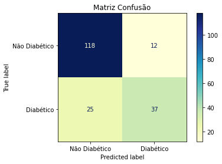

```python
class_names=['Não Diabético','Diabético'] # name  of classes
#
from sklearn.metrics import plot_confusion_matrix

disp = plot_confusion_matrix(classifier, X_test, y_test, display_labels=class_names, cmap="YlGnBu")
disp.figure_.figure = plt.figure(figsize=figsize)
disp.ax_.set_title('Matriz Confusão')
```

# Cálculo da Acurácia, Precisão e Lembrança

- Acurária: $\frac{𝑇_+ + 𝑇_-}{𝑇_+ + 𝑇_- + 𝐹_- + 𝐹_+)}$

```python
print(f"Acurácia : {num_format(metrics.accuracy_score(y_test, y_pred)*100)}%")
print(f"Precisão : {num_format(metrics.precision_score(y_test, y_pred)*100)}%")
print(f"Lembrança: {num_format(metrics.recall_score(y_test, y_pred)*100)}%")
```

```
Acurácia : 80.73%
Precisão : 75.51%
Lembrança: 59.68%
```

Vemos portanto uma acurácia excelente de $80,7\%$, precisão de $75,5\%$ e lembrança de $59,7\%$

# Curva de ROC

- A curva ROC (Receiver Operating Characteristic Curve) leva em conta a TPR (True Positive Rate ou Recall ou Sensitity) e a FPR (False Positive Rate ou Specificity).
- A curva ROC traça esses dois parâmetros. o AUC (Area Under the Curve) é um valor que sintetiza a informação da curva ROC. Ela varia de 0.5 a 1. Em suma, essa métrica nos diz o quanto o modelo é capaz de distinguir as duas classes.

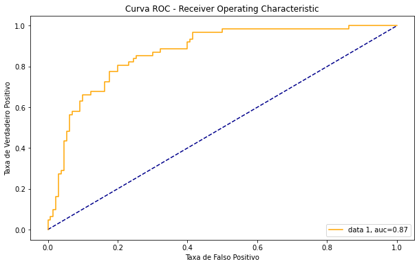

```python
y_pred_proba = logreg.predict_proba(X_test)[::,1]
fpr, tpr, _ = metrics.roc_curve(y_test,  y_pred_proba)
auc = metrics.roc_auc_score(y_test, y_pred_proba)
#
figsize=(10,6)
plt.figure(figsize=figsize)
#
plt.plot([0, 1], [0, 1], color='darkblue', linestyle='--')
plt.plot(fpr, tpr, color='orange', label="data 1, auc="+str(round(auc,2)))
plt.xlabel('Taxa de Falso Positivo')
plt.ylabel('Taxa de Verdadeiro Positivo')
plt.title('Curva ROC - Receiver Operating Characteristic')
plt.legend(loc=4)
plt.show()
```

# Regra de Negócio

```python
X_pred['diabetes_pred_cutoff'] = X_pred['diabetes_proba'].apply(lambda p : 1 if p >= 0.20 else 0)
X_pred[(X_pred['diabetes_test'] != X_pred['diabetes_pred_cutoff']) & (X_pred['diabetes_test'] == 1)].sort_values(by=['diabetes_proba', 'diabetes_test'], ascending=False)
```

|  | pregnant | glucose | bp | bmi | pedigree | diabetes_test | diabetes_pred | diabetes_proba | diabetes_pred_cutoff |
| --- | --- | --- | --- | --- | --- | --- | --- | --- | --- |
| 170 | 6 | 102 | 82 | 30.8 | 0.180 | 1 | 0 | 0.163567 | 0 |
| 706 | 10 | 115 | 0 | 0.0 | 0.261 | 1 | 0 | 0.069076 | 0 |

## Matriz Confusão após a Regra de Negócio

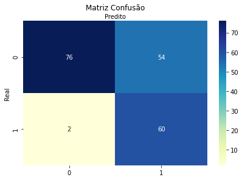

```python
ct = pd.crosstab(X_pred['diabetes_test'], X_pred['diabetes_pred_cutoff'])

fig, ax = plt.subplots()
tick_marks = np.arange(len(class_names))
plt.xticks(tick_marks, class_names)
plt.yticks(tick_marks, class_names)
# create heatmap
sns.heatmap(pd.DataFrame(ct), annot=True, cmap="YlGnBu" ,fmt='g', xticklabels=True)
ax.xaxis.set_label_position("top")
plt.tight_layout()
plt.title('Matriz Confusão', y=1.1)
plt.ylabel('Real')
plt.xlabel('Predito')
```

```python
tp = ct[1][1]
fp = ct[1][0]
fn = ct[0][1]
tn = ct[0][0]


acur = (tp+fp)/(tp+fp+tn+fn)
prec = tp/(tp+fp)
rec = tp/(tp+fn)
print(f"Acurácia : {num_format(acur*100)}%")
print(f"Precisão : {num_format(prec*100)}%")
print(f"Lembrança: {num_format(rec*100)}%")
```

[output not shown]